# Communicate Findings on Proser Loan Data

## by Moaz Mohammed El-Essawey

## Investigation Overview

We will take a look of the data and how it features affect the **Borrower Annual Percentage Rate** and how other features interact together to affect the APR and the Prosper Rating.

## Dataset Overview

The Dataset contains `83,982` entries for `14` columns including (BorrowerAPR, ProsperRating, StatedMonlthyIncome, LoanOriginalAmount) and other.

## The Distrebution of Borrower Annual Percentage Rate.

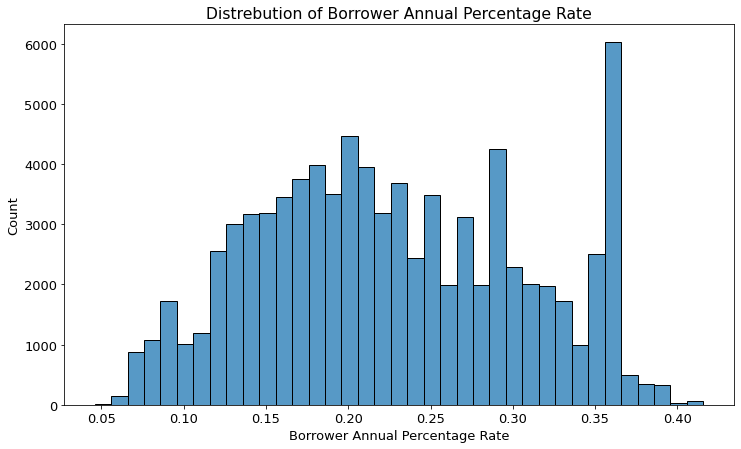

```python
plt.figure(figsize=(12, 7))
borrower_apr_bins = np.arange(
    df['BorrowerAPR'].min(),
    df['BorrowerAPR'].max(),
    0.01
)
sb.histplot(data=df, x='BorrowerAPR', bins=borrower_apr_bins)
plt.title('Distrebution of Borrower Annual Percentage Rate');
plt.xlabel('Borrower Annual Percentage Rate')
plt.ylabel('Count');
```

## Distrebution of Loan Amount

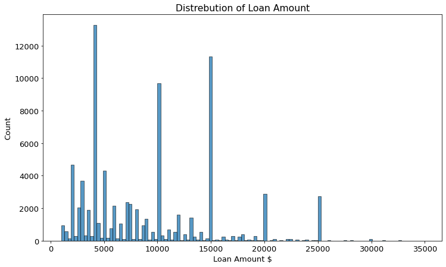

```python
plt.figure(figsize=(12, 7))
loan_amountbins = np.arange(
    df['LoanOriginalAmount'].min(),
    df['LoanOriginalAmount'].max(),
    300.
)
sb.histplot(data=df, x='LoanOriginalAmount', bins=loan_amountbins)
plt.title('Distrebution of Loan Amount');
plt.xlabel('Loan Amount $');
plt.ylabel('Count');
```

## Amount of Loans in each Borrower State

**California** has the highest loans count with value approximately `10K` inside U.S followd by **NewYork City**. with value approximately `5K`.

[figure not shown]

## Relation between Prosper Rating and Borrower Annual Percentage Rate.

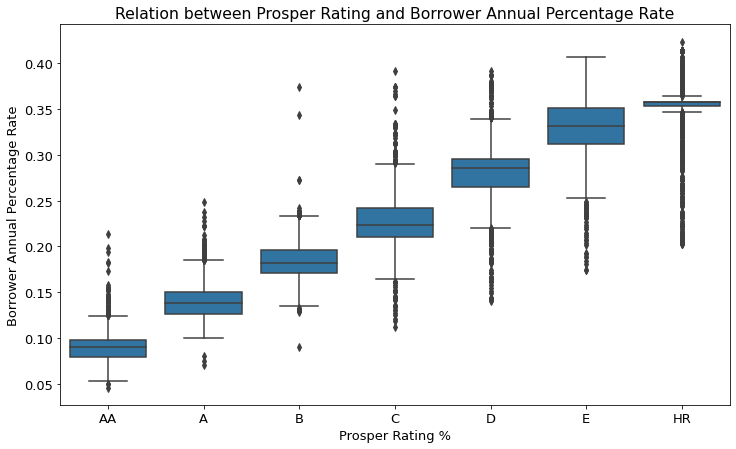

```python
plt.figure(figsize=(12, 7))

sb.boxplot(data=df, x='ProsperRating (Alpha)', y='BorrowerAPR',
           color=base_color, order=prosper_rating_order)
plt.title('Relation between Prosper Rating and Borrower Annual Percentage Rate');
plt.xlabel('Prosper Rating %')
plt.ylabel('Borrower Annual Percentage Rate');
```

## Relation between the Income Range and Prosper Rating.

the ProsperRating has an impact on the IncomeRange and the number of loan associated with each. as in **IncomeRanges** in (**25K:50K**, **50K:75K**, **75K:100K**) has a Prosper Rating as **C**. and in the **>100K** we start to see that the Borrowers with **A** and **AA** increasing.

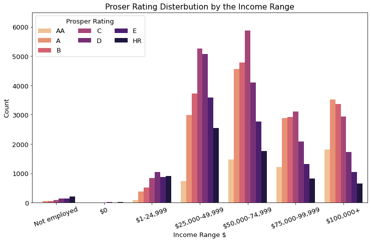

```python
plt.figure(figsize=(12, 7))
sb.countplot(data=df, x='IncomeRange', hue='ProsperRating (Alpha)',
             palette='magma_r', order=income_range_order, hue_order=prosper_rating_order)
plt.xticks(rotation=20);
plt.ylim((0, 6500))
plt.legend(ncol=3, loc='upper left', title='Prosper Rating');
plt.title('Proser Rating Disterbution by the Income Range');
plt.xlabel('Income Range $');
plt.ylabel('Count');
```

## Relation between Loan Amount and Borrower Annual Percentage Rating.

The data has a Negative Correlation as the **LoanOriginalAmount** increases the **BorrowerAPR** tends to decrease.  
most of the loans lies between (**0**, **15K**) and small portion lies between the (**25K**, **35K**)

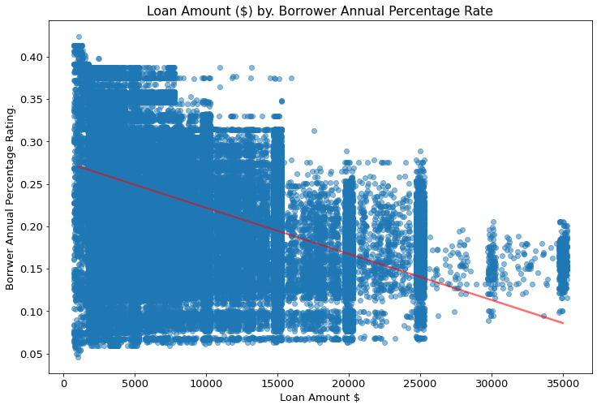

```python
plt.figure(figsize=(12, 8))
sb.regplot(data=df, x='LoanOriginalAmount', y='BorrowerAPR',
           scatter_kws={'alpha':.5}, line_kws={'alpha': .5, 'color': 'r'}, x_jitter=300)
plt.title('Loan Amount ($) by. Borrower Annual Percentage Rate');
plt.xlabel('Loan Amount $');
plt.ylabel('Borrwer Annual Percentage Rating.');
```

## Relation between the Loan Amount and Borrower Annual Percentage Rate and effect of Prosper Rating.

**ProsperRating** has a great effect on the relation between **LoanOriginalAmount** and **BorrowerAPR** as the overall relation is **Negative** but the relation differ from one **ProsperRating** to another as it:

- **Negative** for: (HR ,E ,D ,C ,B)
- **Positive** for : (AA, A)

which means that the clients with (**A**, **AA**) rating when the Loan Amount increases the BorrowerAPR increases.

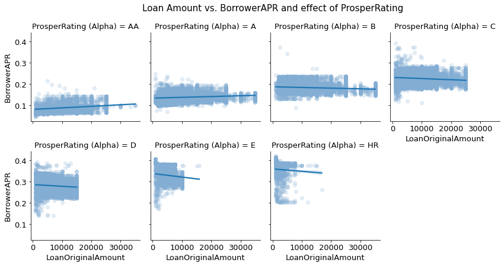

```python
g = sb.FacetGrid(data=df, col='ProsperRating (Alpha)', col_wrap=4,
                 margin_titles=True, col_order=prosper_rating_order)
g.map(sb.regplot, 'LoanOriginalAmount', 'BorrowerAPR',
      scatter_kws={'alpha': .2, 'color': '#83add3'})
plt.text(x=.5, y=1.1, ha='center', fontsize=15,
         s='Loan Amount vs. BorrowerAPR and effect of ProsperRating');
```

## Borrower Annual Percentage Rate vs. Proser Rating and Term

For **ProsperRating** relation with **BrowerAPR** we see intersting outcomes as

- the **Term** increase for Borrowers with (**A**, **AA**, **B**) we see increase in teh **BorrowerAPR**.
- and for the (**C**,**D**,**E**) we that is opposite of that as it started to decrease as the **Term** increased

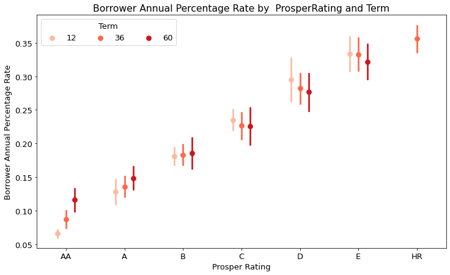

```python
fig = plt.figure(figsize = [12,7])
sb.pointplot(data = df, x = 'ProsperRating (Alpha)',
                  y = 'BorrowerAPR', hue = 'Term', palette = 'Reds',
                  linestyles = '', dodge = .3, ci='sd', order=prosper_rating_order
)
plt.title('Borrower Annual Percentage Rate by  ProsperRating and Term')
plt.ylabel('Borrower Annual Percentage Rate');
plt.xlabel('Prosper Rating');
plt.legend(ncol=3, title='Term');
```